# Hydrating

Jae Yeon Kim

# 1 Objectives

- Learning how hydrating works
- Learning how to use [Twarc](https://github.com/DocNow/twarc) to communicate with Twitter’s API

**Review question**

What are the main two types of Twitter’s API?

# 2 Hydrating: An Alternative Way to Collect Historical Twitter Data

You can collect Twitter data using Twitter’s API or hydrate Tweet IDs collected by other researchers. This is an excellent resource for collecting historical Twitter data.

- [Covid-19 Twitter chatter dataset for scientific use](http://www.panacealab.org/covid19/) by Panacealab
- [Women’s March Dataset](https://dataverse.harvard.edu/dataset.xhtml?persistentId=doi:10.7910/DVN/5ZVMOR) by Littman and Park
- Harvard Dataverse has a number of dehydrated Tweet IDs that could be of interest to social scientists.

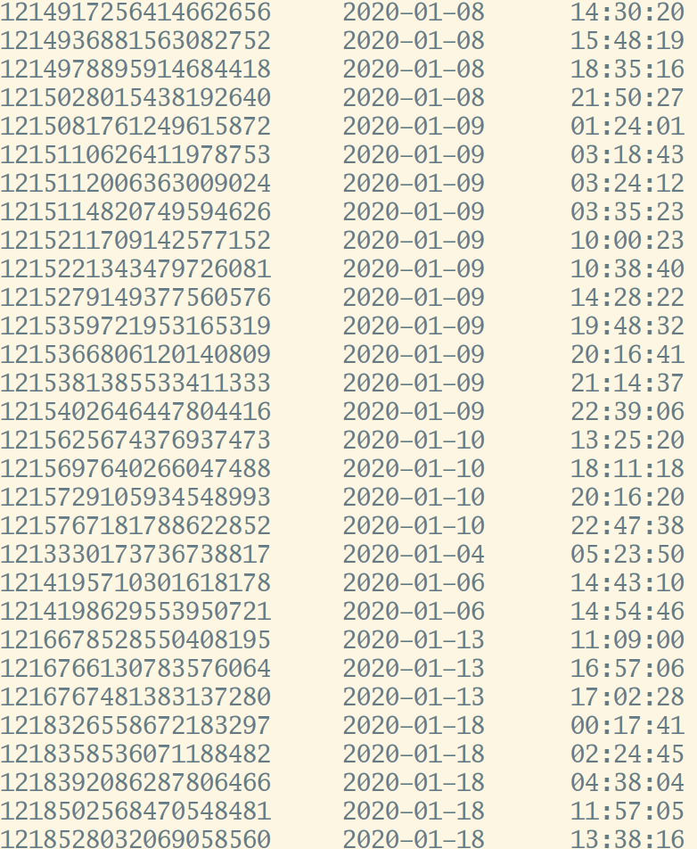

Dehydrated Tweet IDs

# 3 Twarc: one solution to (almost) all Twitter’s API problems

- Why Twarc?
  - A command-line tool and Python library that works for almost every Twitter’s API related problem.
  - It’s really well-documented, tested, and maintained.
    - [Twarc documentation](https://scholarslab.github.io/learn-twarc/06-twarc-command-basics) covers basic commands.
    - [Tward-cloud documentation](https://twarc-cloud.readthedocs.io/_/downloads/en/stable/pdf/) explains how to collect data from Twitter’s API using Twarc running in [Amazon Web Services](https://aws.amazon.com/) (AWS).
  - Twarc was developed as part of the [Documenting the Now](https://www.docnow.io/) project, which the Mellon Foundation funded.

[figure not shown]

One ring that rules them all.

- There’s no reason to be afraid of using a command-line tool and Python library, even though you primarily use R. It’s easy to embed [Python code](https://bookdown.org/yihui/rmarkdown/language-engines.html#python) and [shell scripts](https://bookdown.org/yihui/rmarkdown/language-engines.html#shell-scripts) in R Markdown.
- Even though you don’t know how to write Python code or shell scripts, it’s really useful to know how to integrate them into your R workflow.
- I assume that you have already installed [Python 3](https://www.python.org/download/releases/3.0/).

```bash
pip3 install twarc
```

## 3.1 Applications

The following examples are created by [the University of Virginia library](http://digitalcollecting.lib.virginia.edu/toolkit/docs/social-media/twarc-commands/).

### 3.1.1 Search

- Download pre-existing tweets (7-day window) matching certain conditions
- In command-line, `>` = Create a file
- I recommend running the following commands in the terminal because it’s more stable than in R Markdown.

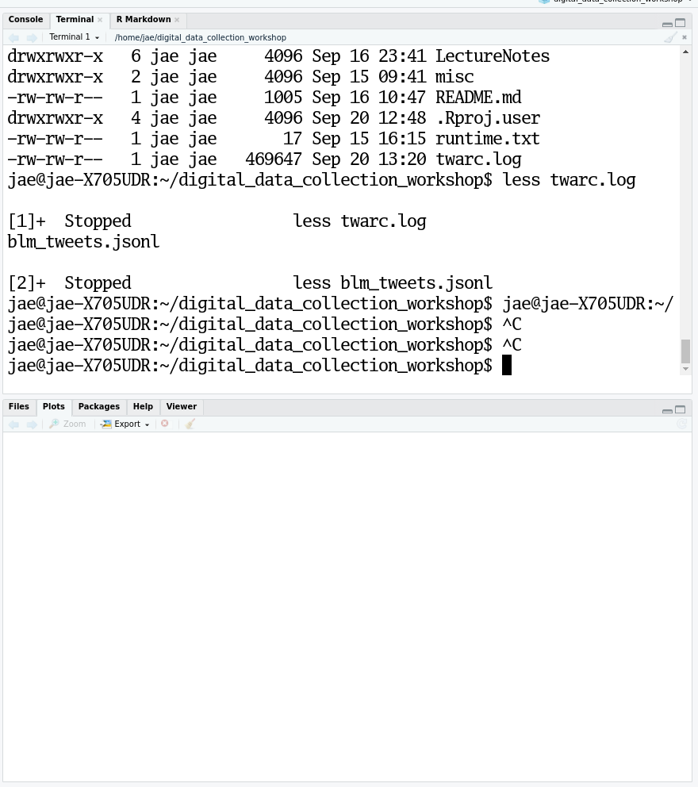

You can type commands in the Terminal in R Studio.

```bash
# Key word
twarc search blacklivesmatter > blm_tweets.jsonl
```

```bash
# Hashtag
twarc search '#blacklivesmatter' > blm_tweets_hash.jsonl
```

```bash
# Hashtag + Language
twarc search '#blacklivesmatter' --lang en > blm_tweets_hash.jsonl
```

- It is really important to **save these tweets into a `jsonl` format;** `jsonl` extension refers to JSON **Lines** files. This structure is useful for splitting JSON data into smaller chunks if it is too large.

### 3.1.2 Filter

- Download tweets meeting certain conditions as they happen.

```bash
# Key word
twarc filter blacklivesmatter > blm_tweets.jsonl
```

### 3.1.3 Sample

- Use Twitter’s random sample of recent tweets.

```bash
twarc sample > tweets.jsonl
```

### 3.1.4 Hydrate

- Tweet IDs -> Tweets

```bash
twarc hydrate tweet_ids.txt > tweets.jsonl
```

### 3.1.5 Dehydrate

- Hydrate <> Dehydrate
- Tweets -> Tweet IDs

```bash
twarc dehydrate tweets.jsonl > tweet_ids.txt
```

**Challenge**

1. Collect tweets containing some keywords of your choice using `twarc search` and save them as `tweets.jsonl`.
2. Using `less` command in the terminal, inspect `twarc.log`.
3. Using `less` command in the terminal, inspect `tweets.json`.